# Concurso de acceso a Catedrático de Universidad

Área de conocimiento: Métodos Cuantitativos para la Economía y la Empresa  
Plaza 573 · Código 78/2026 · Resolución de 23 de junio de 2026 de la Universitat de València

Candidato: Juan de Dios Montoro Pons

Departament d’Economia Aplicada · Universitat de València

24 septiembre 2026

# Parte 1 de 3 Currículum

Parte 1 · Currículum · Parte 2 · Propuesta docente · Parte 3 · Propuesta investigadora: Creative collaborations

## Trayectoria académica

[figure not shown]

# Investigación y transferencia

Parte 1 · Currículum · Parte 2 · Propuesta docente · Parte 3 · Propuesta investigadora: Creative collaborations

Investigación y transferencia · Docencia · Dirección y liderazgo

## Trayectoria investigadora

| Línea | Trabajos representativos | Principales coautores |
| --- | --- | --- |
| **Economía computacional** (1995–2003) | Tesis doctoral “Simulación y Detección de Caos Macroeconómico” (1996) · Capítulos en *Mathematics with Vision* (CMP, 1995) e *Innovations in Mathematics* (CMP, 1997) · *Journal of Macroeconomics* (199… | José V. Paz-García |
| **Elección pública** (1998–2010) | Capítulos en *Methods and Moral in Constitutional Economics. Essays in Honour of James M. Buchanan* (Springer, 2001) y en *Constitutional Economics and Public Institutions* (Edward Elgar, 2013) · *CIR… | Miguel Puchades-Navarro José Casas-Pardo |
| **Economía de la cultura y consumo cultural** (2008–) | Transición vía propiedad intelectual $\to$ participación cultural e industrias creativas y *big data* : *European Journal of Law and Economics* (2008) · *Journal of Cultural Economics* (2011, 2018) · … | Manuel Cuadrado-García María José Miquel-Romero María Caballer-Tarazona María Luisa Palma-Martos |

## Producción científica en cifras

[figure not shown]

| Web of Science | Scopus | Google Scholar |
| --- | --- | --- |
| 251 citas · h = 8 | 335 citas · h = 8 | 807 citas · h = 14 · i10 = 19 |

## Publicaciones seleccionadas

| Trabajo | Revista, año | Indicios | Citas (WoS · Scopus · GS) |
| --- | --- | --- | --- |
| **Live and prerecorded popular music consumption** | *J. of Cultural Economics*, 2011 | JCR **Q2** (Economics) | 45 · 54 · 124 |
| **Religiosity and cultural consumption** | *Int. J. of Consumer Studies*, 2018 | JCR **Q1** (Business) | 23 · 27 · 40 |
| **From pirates to subscribers: 20 years of music consumption research** | *Int. J. of Consumer Studies*, 2021 | JCR **Q1** (Business) | 20 · 25 · 37 |
| **Analyzing online search patterns of music festival tourists** | *Tourism Economics*, 2021 | JCR **Q1** (Economics) | 8 · 8 · 12 |
| **Music festivals as mediators and their influence on consumer awareness** | *Poetics*, 2020 | JCR **Q1** (Sociology) | 4 · 6 · 20 |
| **“Let’s make lots of money”: performance in the recorded music sector** | *J. of Cultural Economics*, 2018 | JCR **Q2** (Economics) | 6 · 7 · 15 |
| **Assessing complementarities between live performances and YouTube video streaming** | *Empirical Economics*, 2023 | JCR **Q2** (Economics) | 3 · 4 · 8 |
| **Arts and cultural consumption and diversity research: a bibliometric analysis** | *Poetics*, 2025 | JCR **Q1** (Sociology) | 1 · 2 · 3 |

## Capítulos de libro

| Capítulo | Obra · editorial, año |
| --- | --- |
| **Evolution and learning in collective decision-making** | Homenaje a J. M. Buchanan (*Methods and Moral in Constitutional Economics*) · **Springer**, 2001 |
| **Empirical insights into recorded music consumer behavior and copyright infringement** | *Music and Law* · **Emerald**, 2013 |
| **Regulator preferences and lobbying efforts in rent-seeking contest** | *Constitutional Economics and Public Institutions* · **Edward Elgar**, 2013 |
| **Copyright infringement and cultural participation** | *Digital Piracy: A Global, Multidisciplinary Account* · **Routledge**, 2018 |
| **Breaking the gender gap in Rap/Hip-Hop consumption** | *Music as Intangible Cultural Heritage* · **Springer**, 2021 |
| **Digital participation and audience enlargement in classical and popular music** | *Digital Transformation in the Cultural and Creative Industries* · **Routledge**, 2021 |
| **Measuring customer multi-sensory experience in live music** | *The Oxford Handbook of Arts and Cultural Management* · **Oxford University Press**, 2022 |

Selección por editorial académica internacional · **29 capítulos y libros** en total · 4 casos docentes en el manual *Marketing Culture and the Arts* (HEC Montréal) y sus ediciones francesas.

## Comunicaciones en congresos

[figure not shown]

Total: 118 ponencias · 92 de carácter internacional

## Proyectos de I+D+i en convocatoria pública

| Proyecto | Convocatoria | Años | Participación |
| --- | --- | --- | --- |
| Teoría del caos: evolución, predicción y control de sistemas | Generalitat Valenciana (AE98-08) | 1998 | equipo |
| Deficiencias en el funcionamiento de las instituciones democráticas | CICYT (SEC99-0592) | 1999–2003 | equipo |
| Teoría del caos: autoorganización y control de sistemas complejos | MCyT (PGC2000-2390-E) | 2001–2002 | equipo |
| Protección del cliente y eficiencia en el sistema financiero (Ley 44/2002) | MCyT (SEC2003-05232) | 2003–2006 | equipo |
| Proyecto de colaboración interdisciplinar, bilingüe y virtual entre universidades de la Unión Europea para la dinamización del proceso de aprendizaje | Ministerio de Ciencia e Innovación | 2008–2009 | equipo |
| MBA-TABSA · Transatlantic Business School Alliance | Comisión Europea (EACEA) | 2010–2014 | IP |
| La regulación de la economía colaborativa | Plan Estatal (DER2015-67613-R) | 2016–2019 | equipo |

## Contratos y convenios de transferencia (art. 83 LOU / 60 LOSU)

| Entidad | Objeto | Años | Participación |
| --- | --- | --- | --- |
| Sociedad Española de Radiodifusión (SER) | Organización y programación de un evento de música, cultura y ocio | 2012–13 | equipo |
| FECEMAC-CV | Indicadores de rendimiento y satisfacción en gestión de la educación musical | 2014–15 | equipo |
| Olympia Metropolitana | Actividades del centenario del Teatro Olympia | 2015–16 | equipo |
| Francachela Teatro | Plan de patrocinio y premios del festival | 2018–19 | IP |
| AVETID | Estudio de públicos Tercera Setmana, 2ª edición | 2018–19 | equipo |
| Francachela Teatro | Plan de patrocinio y premios del festival | 2020–21 | IP |
| Olympia Metropolitana | Estudio de públicos en contexto teatral | 2021–22 | IP |
| A más Soluciones Culturales | Distribución en artes escénicas | 2021–22 | IP |
| Generalitat Valenciana | Perfil y experiencia del visitante del CCCC | 2022–23 | IP |
| ICOM International | SENTOMUS, museums visitors research | 2023–24 | IP |

Total: 16 contratos/convenios con el tejido cultural desde 2012 · IP en 6 · Actividad reconocida con el **sexenio de transferencia** (2012–2017)

## Estancias de investigación

| Estancia | Financiación | Periodo |
| --- | --- | --- |
| Center for Study of Public Choice / J. Buchanan Center, George Mason Univ. (EE. UU.) | Generalitat Valenciana | 1998 · 6 m |
| HEC, Université de Montréal (Canadá) | Universitat de València | 1999 · 1 m |
| CREED, Universiteit van Amsterdam (Países Bajos) | Generalitat Valenciana | 2001 · 4 m |
| HEC, Université de Montréal (Canadá) | Generalitat Valenciana | 2007 · 2 m |
| London School of Economics (Reino Unido) | Universitat de València | 2007 · 2 m |
| Institut für Kulturmanagement, Univ. für Musik und Darstellende Kunst Wien (Austria) | Universitat de València | 2013 · 3 m |

6 estancias oficiales · 5 países · ≈18 meses acumulados · Todas con financiación competitiva (Generalitat Valenciana / Universitat de València)

## Dirección de tesis doctorales

| Título | Autor | Afiliación | Año | Observaciones |
| --- | --- | --- | --- | --- |
| *Segmentación y exhibición cinematográfica: un análisis del mercado español basado en clases latentes* | Desamparados Lluch Tormos | CEU San Pablo (Madrid) | 2017 | Sobresaliente *cum laude* · Tesis doctoral con mención internacional · **Premio Fundación SGAE de Investigación 2018** |
| *Analyzing the effect of the expanded servicescape on visitors’ satisfaction and loyalty in museums* | Piergiacomo Mion Dalle Carbonare | Università Bocconi (Milán) | 2022 | Sobresaliente *cum laude* · Tesis doctoral con mención internacional |
| *Estudio de los determinantes, percepción y valoración del consumidor de música clásica: una aproximación multidisciplinar* | Ariadna Martin-Alfaro | Conservatorio Profesional de Música (Las Palmas de Gran Canaria) | en curso | JCR en revisión |
| *Consumer engagement and market structuring in the contemporary art ecosystem: visitor behavior and responses to citywide interventions* | Giuliano Picchi | MIT (Cambridge, MA) | en curso | Ponencia AIMAC2026 |

# Docencia

Parte 1 · Currículum · Parte 2 · Propuesta docente · Parte 3 · Propuesta investigadora: Creative collaborations

Investigación y transferencia · Docencia · Dirección y liderazgo

## Trayectoria docente

| **Etapa** | **Asignaturas** | **Observaciones** |
| --- | --- | --- |
| **Economía Política (1997)** | Economía Política y Hacienda Pública · Economía (Lic. en CC. y Técnicas Estadísticas) · Estadística e Informática (CC. Empresariales) | Docencia impartida en castellano y valenciano |
| **Métodos Cuantitativos · Modelización e Inferencia Estadística (2006/07)** | Estadística I y II, Estadística Básica, Introducción a la Inferencia Estadística | Integración de troncales en el grupo internacional (ARA) con docencia impartida en inglés |
| **Métodos Cuantitativos · Aprendizaje Estadístico (2019)** | Grado BIA: Datos No Estructurados, Técnicas Avanzadas de Predicción · Máster CD: Inferencia Causal y Aprendizaje Máquina, Ciencia de Datos en Negocio · Máster iMBA: Inteligencia de Negocios · Máster E… | Aumento de la participación como docente en programas de máster |

Docencia en: 7 centros · 13 titulaciones · 18 asignaturas distintas (32 con formación no reglada) · docencia en castellano, inglés (C2) y valenciano (C1) · 50% de la docencia total es en inglés

## Docencia reglada

[figure not shown]

## Docencia internacional

| Destino / centro | Asignatura | Año(s) |
| --- | --- | --- |
| State University of New York at Albany | The World Trade System and the Millenium Round · The Art of Managing Finance II (grado) | 2000 |
| London School of Economics and Political Science | Seminario “Economía y Música — Análisis y Perspectivas de la Industria” | 2007 |
| University of Hertfordshire | Managing the Small Business in the Music Industry (grado) | 2011 |
| University of North Florida | Econometrics (grado) | 2013 |
| University of North Carolina at Wilmington | Statistics · International Marketing (grado) | 2013 |
| Universidad de Buenos Aires | Seminario “Información y toma de decisiones en gestión cultural” (maestría) | 2013 |
| Hochschule Bremen | Statistik I — Quantitative Methoden (grado) | 2018 |
| International Graduate Center (Bremen) | Global Economics (MBA) | 2018 · 2019 |

**Estancias docentes**: 8 estancias oficiales · Docencia en **programas** grado y posgrado

## Evaluación de la docencia

[figure not shown]

**5 quinquenios** (29 cursos con evaluación positiva) · serie de valoraciones ascendente, estable por encima de **4,3** desde 2017 (máximo 4,78 en 2023-24).

## Innovación docente

| Tipo de Actividad | Descripción |
| --- | --- |
| **Grupo de innovación** | Grupo “Multi-aprendizaje, transversalidad y creatividad (MULTI-ATC)” — co-director · Mención de grupo consolidado en 2023 (renovada en 2026) · Continuidad del grupo “Innova multidisciplinar” (2009–201… |
| **Proyectos dirigidos** | Proyectos dirigidos como IP: “Jornada docente transversal y solidaria” (2021/22) · “Investigación b-smart y aprendizaje basado en un proyecto en un centro cultural” (2022/23) · “Danza, salud e investi… |
| **Comunicaciones** | Comunicaciones (28): series recurrentes CIDUI (2006–2012) · Trobades/Jornades d’Innovació Educativa UV (2010–2022) · Xarxes–REDES-INNOVAESTIC (2009–2021) · WCES (2010, 2012) · Congreso Internacional d… |
| **Publicaciones** | Publicaciones: Procedia — Social and Behavioral Sciences (2010 — derivada del piloto en línea con la LSE y la más citada del perfil, 223 citas GS — y 2012) · Rev. Iberoamericana de Educación (2010) · … |

14 **proyectos** (3 como IP) · Co-director del **grupo de innovación consolidado** (mención 2023, renovada 2026) · 28 **comunicaciones** en congresos y jornadas · **Publicaciones**: 5 artículos + 1 capítulo

# Dirección y liderazgo

Parte 1 · Currículum · Parte 2 · Propuesta docente · Parte 3 · Propuesta investigadora: Creative collaborations

Investigación y transferencia · Docencia · Dirección y liderazgo

## Gestión universitaria

| **Cargo** | **Periodo** | **Ámbito** |
| --- | --- | --- |
| **Coordinador de título** Graduado Europeo en Dirección de Empresas | 2010–14 | Facultat d’Economia: titulación internacional |
| **Representante** en la Transatlantic Bussines School Alliance | 2010–14 | Facultat d’Economia: redes internacionales |
| **Coordinador de intercambios** del grado ADE-GEDE | 2010–14 | Vicerrectorado de Relaciones Internacionales y Cooperación, Universitat de València: dobles titulaciones |
| **Coordinador de intercambios** del grado en Negocios Internacionales/International Business | 2011–14 | Vicerrectorado de Relaciones Internacionales y Cooperación, Universitat de València: dobles titulaciones |
| **Miembro de la Comisión de Intecambio de Estudiantes** | 2010–12 | Vicerrectorado de Relaciones Internacionales y Cooperación, Universitat de València: política de internacionalización |
| **Miembro de la Comisión de Relaciones Internacionales** | 2012–14 | Vicerrectorado de Relaciones Internacionales y Cooperación, Universitat de València: política de internacionalización |
| **Miembro Comisión de Intercambio de la Facultat d’Economia** | 2010–2014 | Vicedecanato de Relaciones Internacionales |
| **Miembro de la CCA** del Máster en Ciencia de Datos | 2021– | Escola Tècnica Superior d’Enginyeria: posgrado en datos |

**17 cargos y tareas de gestión**, principalmente en **internacionalización**

## Liderazgo docente e internacionalización

[output not shown]

## Liderazgo investigador

| **Grupo de investigación** | **Dirección de CREAMARKT** (GIUV2020-47) desde 2022 · Grupo reconocido desde 2020 · colaboraciones con HEC Montréal y el Institut für Kulturmanagement (Viena) · Sucesor del grupo OTRI **Arts Managemen… |
| --- | --- |
| **Asociaciones** | Fundador, miembro de la junta y **vicepresidente de IMBRA** (International Music Business Research Association, Viena) · **Miembro de ACEI** · **Miembro de AIMAC** |
| **Edición científica** | **Editor invitado** del número especial “Arts Consumption, Diversity and Inclusion”, *Int. J. of Arts Management* 25(3), 2023 (JCR/SSCI) |
| **Comités científicos** | **Copresidencia del comité científico AIMAC 2007** (València) · Presidencia de la sesión plenaria de apertura de AIMAC 2007 · Participación paneles de evaluación en 11 ediciones de AIMAC (2005–2026) ·… |
| **Evaluación científica** | **36 revisiones verificadas** para 15 revistas (percentil 91) · reconocimiento de *Poetics* (Q1) a la actividad evaluadora (2026) |

## Otras actividades de liderazgo y participación en la vida universitaria

| **Reconocimientos** | Reconocimiento de *Poetics* (JCR Q1) a la actividad evaluadora (2026) · Mención de **grupo consolidado** de innovación docente (2023, renovada 2026) |
| --- | --- |
| **Premios** | Finalista a mejor ponencia, AIMAC 2013 (Universidad de los Andes, Bogotá) · **Premio Fundación SGAE de Investigación 2018** (tesis presentada por Desamparados Lluch) |
| **Conferencias y seminarios por invitación** | Seminario en CREED, Universiteit van Amsterdam (2001) · London School of Economics (2007) · Institut für Kulturmanagement, Universität für Musik Wien (2013) · Panel on “Double Degrees”, University of … |
| **Evaluación externa** | Proyectos de tesis en Télécom ParisTech (2013), University of Applied Sciences Berlin (2015) y Stockholm University (2020) · TFM en Hannover University of Music, Drama and Media (2013) · Tesis en la U… |
| **Tribunales y comisiones** | 3 tribunales de tesis doctorales · 3 comisiones de plazas de profesorado (UPV/EHU 2011, U. de Valladolid 2013, CEU 2019) |
| **Jornadas académico-profesionales** | Organización de **5 jornadas** con el sector cultural: “Nuevas Fórmulas de Gestión en Artes Escénicas: los festivales” (2015) · “Marketing y Festivales de Artes Escénicas en Valencia” (2016) · “Divers… |
| **Divulgación** | Observatorio Social de “la Caixa” (2019) · EconomistsTalkArt (2018, 2025) |

## Síntesis: el currículum en cifras

[figure not shown]

# Parte 2 de 3 Propuesta docente

Parte 1 · Currículum · Parte 2 · Propuesta docente · Parte 3 · Propuesta investigadora: Creative collaborations

# Técnicas avanzadas de predicción

Parte 1 · Currículum · Parte 2 · Propuesta docente · Parte 3 · Propuesta investigadora: Creative collaborations

Técnicas avanzadas de predicción · Proyecto final · Tema 7. Predicción y efectos causales

## Grado en inteligencia y analítica de negocios: BIA

| **Centro** | Facultat d’Economia |
| --- | --- |
| **Duración** | 4 cursos · 240 ECTS |
| **Acceso** | 50 plazas |
| **Modalidad** | Presencial |
| **Materias** | 30 |
| **Asignaturas** | 44 |
| **Campo de estudio** | Ciencias Económicas, Administración y Dirección de Empresas, Marketing, Comercio, Contabilidad y Turismo |

**Objetivo**: Formar profesionales en tecnologías de datos capaces de aplicarlas creativamente a las necesidades empresariales y a los retos de la economía digital.

Para ello integra tres ámbitos:

- **Empresa:** estrategia, finanzas, contabilidad y marketing;
- **Métodos cuantitativos:** matemáticas, estadística y aprendizaje estadístico, y econometría;
- **Tecnología:** programación, gestión de datos y comunicación de resultados.

**Herramientas y Técnicas del Análisis de Datos**

La asignatura **Técnicas Avanzadas de Predicción en Negocios** (dentro de la materia **Herramientas y Técnicas del Análisis de Datos**) se apoya en los tres ámbitos: incorpora en el curriculum modelos predictivos avanzados en un entorno computacional junto con herramientas para valorar su utilidad en la toma de decisiones empresariales.

La asignatura busca formar profesionales con conocimientos de métodos computacionales y modelos predictivos aplicados a economía y negocios tanto para predecir como para explicar, con práctica real y uso crítico de la IA.

## Herramientas y técnicas de análisis de datos

| Asignatura | Curso (cuatr.) | Ámbito | Aportación principal |
| --- | --- | --- | --- |
| Minería de Datos en Negocios | 2 (1) | Exploración | Segmentación, reducción de dimensión, reglas de asociación, árboles |
| Predicción con Datos Transversales | 2 (1) | Predicción | Regresión, GLM, no linealidad, validación, regularización, KNN |
| Predicción con Datos Temporales | 2 (2) | Predicción | Componentes, alisado, ARIMA, evaluación por horizonte |
| **Técnicas Avanzadas de Predicción en Negocios** | **3 (1)** | **Predicción** | **GLMs, ensambles, redes neuronales, SVM, predicción y explicación** |
| Muestreo y Encuestas | 3 (2) | Obtención de información | Diseño muestral, cuestionarios, sesgos, datos faltantes e imputación |
| Datos Espaciales y Espacio-Temporales | 3 (2) | Modelización espacial | Exploración espacial, *kriging*, modelos espaciales, predicción con incertidumbre |
| Datos No Estructurados | 4 (1) | Analítica de datos no tabulares | Captura web y redes sociales, texto, imágenes, NLP, recomendación |

## Técnicas avanzadas de predicción en negocios

| **Código** | 36520 |
| --- | --- |
| **Carácter** | obligatoria |
| **Curso** | 3.º · primer cuatrimestre |
| **Materia** | Herramientas y Técnicas de Análisis de Datos |
| **Carga** | 6 ECTS · 150 h |
| **Docencia** | 15 h teoría · 45 h aula informática |
| **Trabajo no presencial** | 90 h |

**Conocimientos previos**

- Análisis exploratorio y minería de datos, inferencia, y técnicas de predicción transversal y temporal
- Uso continuado de `R` en análisis estadístico, minería y predicción
- Fundamentos de programación y algoritmia con `Python`

**Objetivos**

- Implementar y comparar métodos avanzados de aprendizaje automático
- Selección de modelos; interpretación de resultados y límites
- Distinguir preguntas predictivas y explicativas

El **Tema 7** desarrolla el último objetivo mediante un caso de negocio.

## Contenidos y planificación

| **Semanas** | **Tema** | **Práctica / Entrega del proyecto** |
| --- | --- | --- |
| 1 | 1. Fundamentos | Entorno de trabajo reproducible |
| 2–3 | 2. Selección y evaluación | Validación cruzada e hiperparámetros / S2: grupos y dataset del proyecto |
| 4–5 | 3. Modelo lineal generalizado con regularización | Modelo base: GLM sobre conjunto de datos de referencia / S4: EDA |
| 6–8 | 4. Ensambles: RF, XGBoost y *stacking* | Competición contra el modelo base / S6: modelo base del proyecto · S8: ensambles del proyecto |
| 9 | 5. Máquinas de vectores de soporte (SVM) | Comparación transversal de modelos / S9: SVM |
| 10–12 | 6. Redes neuronales y aprendizaje profundo | Keras / S10: revisión y retroalimentación |
| **13–14** | **7. Predicción y efectos causales** | **Simulación de sesgos + workflow `DoubleML` / S13: extensión causal** |
| 15 | Evaluación | S15: defensa oral del proyecto |

**El conjunto de datos de referencia**

A lo largo de la asignatura utilizamos un mismo conjunto de datos como caso de estudio transversal, sobre el que aplicamos las diferentes técnicas. Esto permite comparar los modelos en un contexto común, analizar sus fortalezas y limitaciones, y comprender qué métodos resultan más adecuados según el objetivo empresarial y las características de los datos.

## Metodología docente: carga de trabajo

| Modalidad | Actividad | Horas semanales | Horas totales |
| --- | --- | --- | --- |
| **Presencial** | Teoría: presentación del problema, conceptos y discusión | 1 h | 15 h |
| **Presencial** | Práctica: notebook guiado, trabajo autónomo y entregas | 3 h | 45 h |
| **No presencial** | Trabajos individuales/grupo | 2 h 20 min | 35 h |
| **No presencial** | Estudio y trabajo autónomo | 2 h 20 min | 35 h |
| **No presencial** | Resolución de casos | 1 h | 15 h |
| **No presencial** | Preparación de la evaluación | 20 min | 5 h |

Carga total 150 h · 60 h presenciales · 90 h no presenciales

## Metodología docente: secuencia de aprendizaje

[figure not shown]

Las sesiones prácticas desarrollan los contenidos de la teoría y producen evidencias de aprendizaje durante todo el cuatrimestre.

## Recursos didácticos

| Tipo de recurso | Elementos | Uso |
| --- | --- | --- |
| **Software y bibliotecas** | `Python`, `scikit-learn`, `Keras` y `DoubleML` | Implementación y comparación de métodos |
| **Entornos de trabajo** | `Jupyter`, Google Colab, IDE y entorno `conda` versionado | Desarrollo, acceso y ejecución reproducible |
| **Materiales expositivos** | Notas, presentaciones y ejemplos de código | Introducción y explicación de los contenidos |
| **Materiales prácticos** | Notebooks guiados, ejercicios y datos reales | Aplicación progresiva de los métodos |
| **Recursos interactivos** | Simulaciones y visualizaciones | Exploración de concepts: p.e. sesgo, incertidumbre y variabilidad, o entrenamiento de redes neuronales |
| **Recursos para la evaluación** | Cuestionarios breves y actividades de autoevaluación | Seguimiento y retroalimentación |
| **Recursos para la reproducibilidad** | Repositorio de la asignatura y plantillas | Organización, documentación y reutilización |
| **Bibliografía** | James et al., **ISLP** (2023) + lecturas específicas y documentación de bibliotecas | Fundamentación y ampliación de contenidos |

## Evaluación

[figure not shown]

- **Proyecto (35%)**: aplicación integrada de los contenidos y defensa oral.
- **Entregas (30%) y participación (10%)**: seguimiento del trabajo individual durante el curso.
- **Examen (25%)**: preguntas teóricas y aplicadas; se exige un mínimo de **5/10**.

Los pesos, las rúbricas y las condiciones de recuperación se publican al inicio del curso.

# Proyecto final

Parte 1 · Currículum · Parte 2 · Propuesta docente · Parte 3 · Propuesta investigadora: Creative collaborations

Técnicas avanzadas de predicción · Proyecto final · Tema 7. Predicción y efectos causales

## Proyecto del cuatrimestre

[figure not shown]

- Grupos de 3–4 alumnos, dataset y problema propios elegidos en la semana 2; cada entrega se basa en el contenido desarrollado durante esas semanas
- El hito de la S13 permite formular una pregunta causal sobre los propios datos y responderla con `DoubleML` (o justificar por qué los supuestos no lo permiten)
- Entrega final: **repositorio reproducible + memoria + defensa oral**

## Rúbrica del proyecto

| **Dimensión (peso)** | **Qué se evalúa** | **Excelente (9–10)** | **Apto (5–6)** | **No apto** |
| --- | --- | --- | --- | --- |
| **Formulación y datos (10%)** | Pregunta relevantes, dataset, EDA | pregunta orientada a toma decisiones susceptible de respuesta empírica; limitaciones de los datos discutidas | Pregunta clara, EDA correcto | Dataset sin justificar; pregunta ambigua; EDA ausente |
| **Proyecto reproducible (15%)** | Repositorio, entorno, ejecución (*pipeline*) | Reproduce todo desde datos crudos, entorno versionado | Reproducible con intervención menor documentada | No reproduce; preprocesado fuera del pipeline (fuga) |
| **Modelización (25%)** | Modelo base → ensambles → SVM → DL; comparación | Comparación honesta en test común; selección justificada | $\geq$ 3 familias comparadas correctamente; métricas incompletas | Sin modelo base; métricas elegidas a posteriori |
| **Interpretación y comunicación (20%)** | Memoria, figuras, lectura de resultados | Resultados traducidos a decisión de negocio; incorpora incertidumbre | Interpretación correcta de métricas y efectos | Lectura mecánica o errónea de las salidas |
| **Defensa oral individual (30%)** | 10’ grupo + preguntas individuales | Cada miembro explica y modifica en vivo cualquier parte del código | Cada miembro explica las partes que firmó | Un miembro no sabe explicar código propio |

## Uso de inteligencia artificial

**Tres verificaciones (que la IA no suplanta)**

- **Defensa oral individual** con modificación de código en vivo
- **10% de participación en aula** (presencialidad verificada)
- **Examen presencial** (25%) con mínimo de 5/10

**Política de IA: permitida, declarada, auditada**

- Uso libre de asistentes para código, depuración y redacción (favoreciendo uso crítico y responsable)
- **Obligatorio:** el registro completo de prompts se entrega como apéndice del proyecto y de las entregas relevantes
- Evaluado sobre los prompts: el registro se cruza con el código y la memoria buscando coherencia prompts $\leftrightarrow$ trabajo; se valora la transparencia. Alerta si resultado excede lo que el registro explica

# Tema 7. Predicción y efectos causales

Parte 1 · Currículum · Parte 2 · Propuesta docente · Parte 3 · Propuesta investigadora: Creative collaborations

Técnicas avanzadas de predicción · Proyecto final · Tema 7. Predicción y efectos causales

## Riesgo de abandono y estrategia de retención de clientes

**Decisión de negocio**: estimación del riesgo de abandono (*churn*) y estrategia retención de clientes. Analizamos dos reglas de priorización

- **RISK:** actuar sobre quienes tienen mayor probabilidad de abandono.
- **LIFT:** actuar sobre quienes la intervención produce una mayor reducción de la probabilidad de abandono (sensibilidad a la intervención).

La predicción del riesgo de abandono no responde por sí sola a la cuestión de gestión **qué clientes deberían ser objeto de una campaña**. Esta decisión requiere estimar el efecto causal de la intervención.

**Experimentos aleatorios controlados: el patrón de referencia**

Ascarza (2018). “Retention Futility: Targeting High-Risk Customers Might Be Ineffective”, *Journal of Marketing Research*, 55(1), 80–98. DOI: 10.1509/jmr.16.0163.

Un operador de telefonía móvil de prepago de Oriente Medio asignó al azar a 12.137 clientes que habían recargado entre una y cuatro semanas antes y no habían realizado llamadas durante la última semana. El grupo tratado recibió un SMS con crédito adicional si recargaba una cantidad determinada en los tres días siguientes. Se observó si la línea seguía activa 30 días después.

Con los resultados derivados de los datos experimentales se estima qué impacto tendría una campaña de retención sobre un subconjunto de los clientes (40%) usando reglas de priorización alternativas: RISK o LIFT.

| Criterio de selección | Pregunta que responde | Efecto |
| --- | --- | --- |
| Seleccionar el 40% de los clientes con mayor **riesgo** (problema predictivo) | ¿Quién es más probable que abandone? | **-1.9 puntos** |
| Seleccionar el 40% de los clientes con mayor **sensibilidad a la intervención** (problema inferencia causal) | ¿En quién reduce la campaña el abandono? | **-6,0 puntos** |

La diferencia entre ambos criterios fue de **4,1 puntos porcentuales**.

## Aprendizaje automático para la estimación de efectos causales

**Objetivo**: estimar el parámetro $\tau$ para la expresión:
$$y=\tau D+g(X)+\epsilon$$

Con **datos observacionales** $\to$ posible confusión en $X$:

$$D= m(X)+\eta$$

[figure not shown]

**¿Por qué aprendizaje automático?**

- Elevada dimensionalidad de $X$.
- Datos no tabulares (p.e. texto o imágenes).
- Flexibilidad para aproximar $g$ y $m$.

## De la aplicación *naive* al Double Machine Learning

**Estimación *naive* del modelo parcialmente lineal $y=\tau D + g(X)+ \epsilon$**

1. Aprender $\hat{g}$ y residualizar la respuesta: $\tilde{y}=y-\hat{g}(X)$.
2. Regresión de $\tilde{y}$ sobre $D$.

**Double Machine Learning**

1. Aprender $\hat{g}$, $\hat{m}$; residualizar respuesta y tratamiento con *cross-fitting*: $\tilde{y}=y-\hat{g}(X)$, $\tilde{D}=D-\hat{m}(X)$.
2. Regresión de $\tilde{y}$ sobre $\tilde{D}$: $\tilde{y}=\tau\tilde{D}+\epsilon$.

[figure not shown]

## Práctica con datos reales

**Workflow con `DoubleML`**

```python
from doubleml import DoubleMLData, \
   DoubleMLPLR
from sklearn.ensemble import \
   RandomForestRegressor

datos = DoubleMLData(df, y_col="gasto",
                     d_cols="email",
                     x_cols=covariables)

regresor = RandomForestRegressor()

dml = DoubleMLPLR(datos,
                  ml_l=regresor,
                  ml_m=regresor,
                  n_folds=5)
dml.fit()
print(dml.summary)
dml.sensitivity_analysis()
```

**Decisión: ¿a quién enviar la campaña?**

- Los [datos públicos de Hillstrom](https://www.minethatdata.com/Kevin_Hillstrom_MineThatData_E-MailAnalytics_DataMiningChallenge_2008.03.20.csv) incluyen 64.000 clientes asignados al azar a tres grupos: email de productos de hombre, email de productos de mujer y control sin email. Durante dos semanas se observan visitas, compras y gasto.
- Se estima el efecto promedio de la intervención y se comparan dos reglas de priorización: selección por probabilidad de respuesta positiva o por efecto estimado de la campaña.
- En una etapa final se introduce selección observacional y valida `DoubleML` frente al resultado experimental.

**Salida del workflow:** los modelos de primera etapa se evalúan con validación cruzada; `dml` devuelve el efecto estimado, su intervalo de confianza y la sensibilidad a confusión residual.

# Parte 3 de 3 Propuesta investigadora: *Creative collaborations*

Parte 1 · Currículum · Parte 2 · Propuesta docente · Parte 3 · Propuesta investigadora: Creative collaborations

## Resumen de la propuesta en cuatro ideas

| **Colaboración** | Dos artistas graban juntos una canción, el fenómeno *feat.*: **Bad Bunny y J Balvin**, **Taylor Swift y Kendrick Lamar**. Hoy es una práctica frecuente. |
| --- | --- |
| **Elección** | Cada artista podría colaborar con cientos de otros y solo lo hace con unos pocos. ¿Qué distingue a los pares que llegan a trabajar juntos? |
| **Proximidad estética** | En redes sociales el público describe a cada artista con etiquetas (palabras): géneros, estilos, estados de ánimo. **Bad Bunny y J Balvin** son etiquetados con un vocabulario similar (*cercanos*). **T… |
| **Hipótesis** | Estar cerca facilita el encaje: **Bad Bunny** y **J Balvin** han grabado juntos en varias ocasiones. Pero también colaboran artistas lejanos: **Taylor Swift** y **Kendrick Lamar**. ¿Hay un punto a par… |

**Variables adicionales**

Contactos previos en la red de colaboraciones, escena cultural e institucional y trayectoria de cada artista. Datos: quién colabora con quién en las listas globales de Spotify, 2013–2025.

# Motivación y contexto

Parte 1 · Currículum · Parte 2 · Propuesta docente · Parte 3 · Propuesta investigadora: Creative collaborations

Motivación y contexto · Datos y diseño · Resultados · Conclusiones

## Colaboración en la industria de la música

[figure not shown]

Proporción de colaboraciones en el Billboard Hot 100 por año y tramo de la lista, 1970-2025, con ajuste local.

## Marco conceptual

| Pregunta | Qué encuentra la literatura | Referencias |
| --- | --- | --- |
| ¿Beneficios de colaborar? | Los *featurings* elevan la demanda de *streaming*; los duetos sobreviven más en las listas | McKenzie et al. (2021); Kaimann et al. (2021) |
| ¿Qué explica la formación de vínculos? | Mecanismos asortativos, relacionales y de proximidad geográfica e institucional operan a la vez; los lazos previos generan información, visibilidad y oportunidades para nuevos vínculos | Rivera, Soderstrom y Uzzi (2010); Gulati y Gargiulo (1999); Powell et al. (2005) |
| ¿Similares o potencialmente complementarios? | Recursos similares facilitan coordinación y aprendizaje; los distintos aportan novedad si emerge complementariedad; el óptimo interior es una hipótesis extendida en alianzas, innovación y equipos cien… | Mitsuhashi y Greve (2009); Jones (2009); Nooteboom et al. (2007); Uzzi et al. (2013); Smith et al. (2021) |
| ¿Cómo se traduce en la música? | La diferenciación óptima favorece el éxito; la distancia entre géneros permite potencialmente ampliar la demanda; la evidencia es sobre los resultados de las colaboraciones; pero ¿formación? | Askin y Mauskapf (2017); Ordanini, Nunes y Nanni (2018) |

## Contribución: medición y contraste de la afinidad estética

- **Selección de colaboradores**: primeras colaboraciones frente al conjunto completo de pares elegibles.
- **Medición**: perfiles de etiquetas de audiencia asociados a lanzamientos anteriores a cada año.
- **Contraste de forma**: se contrasta un óptimo interior con especificaciones flexibles y una prueba prespecificada de reversión de signo.
- **Validación**: inferencia con dependencia diádica, sensibilidad y evaluación temporal de la ordenación.

# Datos y diseño

Parte 1 · Currículum · Parte 2 · Propuesta docente · Parte 3 · Propuesta investigadora: Creative collaborations

Motivación y contexto · Datos y diseño · Resultados · Conclusiones

## Fuentes de datos

**Cifras básicas**

| Ventana de listas | 2013–2025 |
| --- | --- |
| Pistas × artista | 12.688 |
| Artistas en el ámbito | 2.878 |
| Con etiquetas fechadas | 2.402 |

- **`Spotify`**: listas globales semanales y créditos de pista, álbum y artista (metadatos del API).
- **`Last.fm` y `MusicBrainz`**: etiquetas de audiencia sobre géneros, estilos y otras percepciones (p.e. estados de ánimo).
- **`MusicBrainz` y créditos de álbum**: atributos de artistas e historial de sellos.

**Por qué etiquetas y no géneros de plataforma**

Las etiquetas por lanzamiento cubren el **83,5% de los artistas**. Los géneros de Spotify cubren aproximadamente el **34%**.

## Proximidad estética

- Cada artista es un vector de etiquetas
- La proximidad es la similitud coseno entre vectores
- Cobertura de pares: 93% de pares con similitud observada en 2015; 67% en 2024

[figure not shown]

## Composición de la red

[figure not shown]

## Qué cuenta como primera colaboración

- **Evento**: primera colaboración principal–invitado en una pista que entra en listas.
- **Formación**: exige ausencia de lazos previos entre ambos artistas (también los observados fuera de listas).
- **Pares invitado–invitado**: no cuentan como evento (tampoco como negativos). Asimismo, cualquier posible colaboración **principal-invitado** posterior no es un evento de **formación**.

## Diseño: el conjunto de oportunidades

- **Elegibilidad anual**: ambos artistas debutaron antes de $t$ y publicaron una pista en listas en los tres años anteriores.
- **Conjunto completo de riesgo**: todos los pares no ordenados elegibles para una primera colaboración, sin muestreo de negativos.
- **Muestra de estimación**: 2.256 artistas, 3.756.411 pares-año observados en el periodo 2015–2024.
- **Sensibilidad**: ventana de cinco años y permanencia sin salida tras el debut.

**Evento raro**

Se identifican con 1.064 eventos de formación elegibles sobre 3.756.411 pares-año: **28,3 formaciones por cada 100.000 pares-año de estimación**.

## Estimación

|  | **Logit** | **XGBoost** |
| --- | --- | --- |
| Objetivo | Forma e inferencia de las asociaciones condicionales | Referencia flexible para ordenar pares; asociaciones fuera de muestra; forma similitud estética (no paramétrica) |
| Especificación | Red retardada, características del par y efectos de año | Árboles con interacciones y no linealidades |
| Diseño temporal | Inferencia 2015–2024; predicción reestimada hasta 2023 | Entrenamiento hasta 2022, validación 2023 y reajuste hasta 2023 |
| Evaluación | Ordenación en 2024 | Ordenación en 2024 |
| Incertidumbre | Errores estándar robustos diádicos | Bootstrap de métricas |

**¿Por qué no un ERGM?**

1. Escalabilidad: con 2.256 actores y millones de díadas la estimación es computacionalmente exigente.
2. Objeto probabilístico diferente: distribución conjunta de la red (ERGM) frente a probabilidad diádica condicional (logit).

Seguimos enfoque de Almquist y Butts (2014).

## Bloques de variables y modelos anidados

| Bloque | Qué recoge | Términos |
| --- | --- | --- |
| **Red** | Socios comunes, conexiones y posición en el grafo previo | Vecinos comunes · Índice Jaccard · Índice Adamic–Adar · Conexión preferencial · Alcanzabilidad · Proximidad geodésica · Grado medio · Diferencia de grado |
| **Estética** | Similitud, tipicidad respecto al centroide, amplitud y cobertura de etiquetas | Similitud estética · Similitud estética<sup>2</sup> · Similitud al centroide: media · Similitud al centroide: diferencia · Entropía media · Diferencia de entropía · Tamaño del vocabulario: media · Tam… |
| **Actividad y oportunidad** | Producción en listas, carrera y duración de la elegibilidad conjunta | Pistas en listas: media · Pistas en listas: diferencia · Carrera media · Diferencia de carrera · Elegibilidad: 2–3 años · Elegibilidad: 4–6 años · Elegibilidad: 7+ años |
| **Otras proximidades** | Escena, país, atributos del artista e historia de sellos | Misma escena · Mismo país · Mismo tipo de artista · Mismo género del artista · Índice Jaccard de sellos · Sellos compartidos · Algún sello común |

**Nota**

**Tres modelos anidados**: Completo (los cuatro bloques) · Solo red (topología) · Sin red (estética, actividad y atributos). Las restricciones se contrastan con tests de Wald (errores estándar robustos).

# Resultados · Modelo base

Parte 1 · Currículum · Parte 2 · Propuesta docente · Parte 3 · Propuesta investigadora: Creative collaborations

Motivación y contexto · Datos y diseño · Resultados · Conclusiones

Modelo base · Predicción · Sensibilidad

## Asociaciones del modelo completo

[figure not shown]

**Odds ratios e IC 95%.** Continuas: +1 desviación estándar; binarias: presencia frente a ausencia. Similitud estética y su cuadrado: contrastes separados (el otro término fijo); su lectura conjunta es la curva.

## ¿Máximo o punto de saturación?

La forma cuadrática de la similitud estética sitúa el máximo implícito en **0,637**, en el **percentil 94,8** de la similitud observada. La evidencia es compatible con un máximo o un crecimiento que se estabiliza.

Las distinguimos mediante tres procedimientos:

- **Intervalos de similitud**: tasas ajustadas sin imponer una curva cuadrática.
- **Spline cúbico natural**: perfil flexible con regla de nudos prespecificada.
- **Reversión de signo**: localizar un máximo y estimar la pendiente en mitades separadas de la muestra. **Criterio confirmatorio**: subida anterior y caída posterior.

## Proximidad estética y colaboraciones: especificación flexible

| Resultado | Media | [2,5%, 97,5%] |
| --- | --- | --- |
| $b$ | 0,670 | [0,373; 0,763] |
| $D_{\mathrm{pre}}$ | 2,132 | [1,177; 3,206] |
| $\beta_{\mathrm{post}}$ | 2,496 | [-2,763; 8,586] |

**Contraste de reversión**: Subida anterior y pendiente posterior imprecisa. No se confirma la reversión

[figure not shown]

Curva: predicciones medias del logit con spline. Puntos: tasas ajustadas del logit con similitud por tramos (intervalos de confianza diádicos).

# Resultados · Predicción

Parte 1 · Currículum · Parte 2 · Propuesta docente · Parte 3 · Propuesta investigadora: Creative collaborations

Motivación y contexto · Datos y diseño · Resultados · Conclusiones

Modelo base · Predicción · Sensibilidad

## Capacidad predictiva por bloques de variables

| Especificación | Logit | XGBoost |
| --- | --- | --- |
| Solo red | 0,200 / 31,25 / 15,31 | 0,140 / 21,88 / 11,51 |
| Sin red | 0,230 / 35,94 / 17,61 | 0,180 / 28,13 / 14,80 |
| Completo | 0,270 / 42,19 / 20,67 | 0,200 / 31,25 / 16,45 |

**Celdas**: Precisión@10K (%) / Recall@10K (%) / Lift@10K. Ordenación en 2024 (64 eventos) sobre las 10.000 díadas mejor puntuadas.

## Contraste no paramétrico de la forma funcional

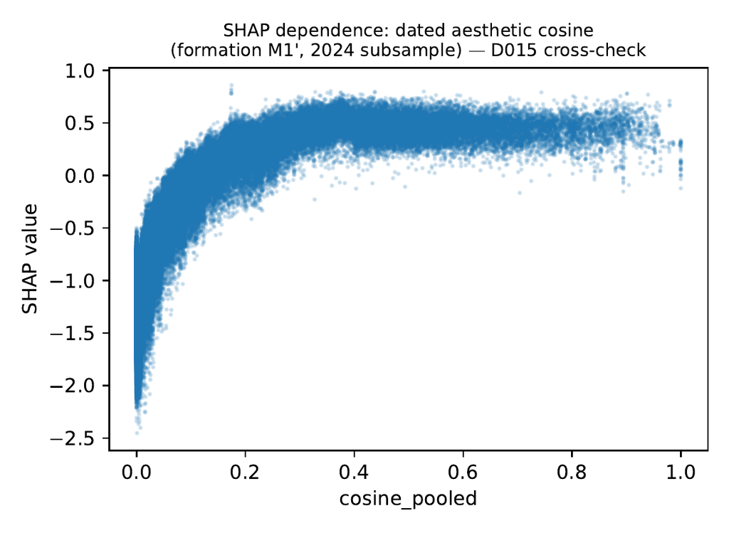

# Resultados · Sensibilidad

Parte 1 · Currículum · Parte 2 · Propuesta docente · Parte 3 · Propuesta investigadora: Creative collaborations

Motivación y contexto · Datos y diseño · Resultados · Conclusiones

Modelo base · Predicción · Sensibilidad

## Firth: estabilidad de las estimaciones

[figure not shown]

**Mayor desplazamiento: 0,23 errores estándar del modelo base.** Comparación descriptiva de estimaciones puntuales. Todos los coeficinetes mantienen el signo.

# Conclusiones

Parte 1 · Currículum · Parte 2 · Propuesta docente · Parte 3 · Propuesta investigadora: Creative collaborations

Motivación y contexto · Datos y diseño · Resultados · Conclusiones

## Síntesis: afinidad, red y oportunidad

[figure not shown]

## Qué aporta estudiar la formación de colaboraciones

- **La formación como etapa económica propia**: determina qué combinaciones creativas llegan a materializarse.
- **La hipótesis de distancia óptima exige precisar la etapa y contrastar la forma**: los resultados sobre éxito no se trasladan automáticamente a la selección de socios.
- **La siguiente pregunta relaciona selección y rendimiento**: quién colabora y qué consigue esa colaboración.

## Alcance y límites de la evidencia

| Límite | Consecuencia para la interpretación |
| --- | --- |
| **Asociaciones** | No se identifican efectos causales |
| **Similitud extrema** | Ocho eventos por encima de 0,90: una penalización sigue siendo una cuestión abierta |
| **Población y cobertura** | Artistas activos en listas con metadatos; medidas culturales e institucionales incompletas |
| **Adecuación de la red simulada** | Reproducir el volumen de vínculos no garantiza reproducir su concentración; la causa de la discrepancia permanece abierta |

# Agradecimientos